# FinalProject

Kush Nagpal

May 12, 2018

This tutorial will provide exploratory data analysis on global temperatures. We are provided with a dataset which lists the mean LandAverageTemperature, LandMaxTemperature, LandMinTemperature, and LandAndOceanAverageTemperature of all locations across the world. The dataset also provides an uncertainty value for each of the attributes.

Using the data, I hope to prove with substantial evidence that global warming is real. If there is a clear increasing relationship between temperature and time, then this would demonstrate that global warming is very real and dangerous.

The following dataset that I am using is: GlobalTemperatures.csv I received a copy of this dataset through Kaggle.

```r
temp_df <- fread('GlobalTemperatures.csv')
temp_df
```

```
##               dt LandAverageTemperature LandAverageTemperatureUncertainty
##    1: 1750-01-01                  3.034                             3.574
##    2: 1750-02-01                  3.083                             3.702
##    3: 1750-03-01                  5.626                             3.076
##    4: 1750-04-01                  8.490                             2.451
##    5: 1750-05-01                 11.573                             2.072
##   ---
## 3188: 2015-08-01                 14.755                             0.072
## 3189: 2015-09-01                 12.999                             0.079
## 3190: 2015-10-01                 10.801                             0.102
## 3191: 2015-11-01                  7.433                             0.119
## 3192: 2015-12-01                  5.518                             0.100
##       LandMaxTemperature LandMaxTemperatureUncertainty LandMinTemperature
##    1:                 NA                            NA                 NA
##    2:                 NA                            NA                 NA
```

[output cut: 33 more lines]

Let’s rename the columns and give them more elegant names. The names provided are relatively long and can be shortened.

```r
temp_df <- temp_df %>% rename(
  date = dt,
  avg_temp = LandAverageTemperature,
  avg_temp_uncertainty = LandAverageTemperatureUncertainty,
  max_temp = LandMaxTemperature,
  max_temp_uncertainty = LandMaxTemperatureUncertainty,
  min_temp = LandMinTemperature,
  min_temp_uncertainty = LandMinTemperatureUncertainty,
  land_ocean_avg_temp = LandAndOceanAverageTemperature,
  land_ocean_avg_temp_uncertainty = LandAndOceanAverageTemperatureUncertainty
)
temp_df
```

```
##             date avg_temp avg_temp_uncertainty max_temp
##    1: 1750-01-01    3.034                3.574       NA
##    2: 1750-02-01    3.083                3.702       NA
##    3: 1750-03-01    5.626                3.076       NA
##    4: 1750-04-01    8.490                2.451       NA
##    5: 1750-05-01   11.573                2.072       NA
##   ---
## 3188: 2015-08-01   14.755                0.072   20.699
## 3189: 2015-09-01   12.999                0.079   18.845
## 3190: 2015-10-01   10.801                0.102   16.450
## 3191: 2015-11-01    7.433                0.119   12.892
## 3192: 2015-12-01    5.518                0.100   10.725
##       max_temp_uncertainty min_temp min_temp_uncertainty
##    1:                   NA       NA                   NA
##    2:                   NA       NA                   NA
```

[output cut: 21 more lines]

We notice that there is a lot of missing data in this data frame. Prior to 1850, the max_temp, max_temp uncertainty, min_temp, min_temp uncertainty, land_ocean_avg_temp and land_ocean_avg_temp uncertainty columns are all reported as NA. The uncertainty columns can be safely be replaced by the mean of all values in the respective columns. By examining the CSV file, I noticed that the max temperature recorded is approximately 6 degrees more than the average temperature and the minimum temperature recorded is approximately 6 degrees less than the average temperature. Therefore, for years < 1850, I will estimate max_temp to be avg_temp + 6 and min_temp to be avg_temp - 6.

```r
for (val in 1:1200) {
  temp_df[val, "max_temp"] = temp_df[val, "avg_temp"] + 6
  temp_df[val, "min_temp"] = temp_df[val, "avg_temp"] - 6
}

temp_df <- temp_df %>%
  replace_na(list(max_temp_uncertainty=mean(.$max_temp_uncertainty, na.rm = TRUE))) %>%
  replace_na(list(min_temp_uncertainty=mean(.$min_temp_uncertainty, na.rm = TRUE))) %>%
  replace_na(list(land_ocean_avg_temp=mean(.$land_ocean_avg_temp, na.rm = TRUE))) %>%
  replace_na(list(land_ocean_avg_temp_uncertainty=mean(.$land_ocean_avg_temp_uncertainty, na.rm = TRUE)))
temp_df
```

```
##             date avg_temp avg_temp_uncertainty max_temp
##    1: 1750-01-01    3.034                3.574    9.034
##    2: 1750-02-01    3.083                3.702    9.083
##    3: 1750-03-01    5.626                3.076   11.626
##    4: 1750-04-01    8.490                2.451   14.490
##    5: 1750-05-01   11.573                2.072   17.573
##   ---
## 3188: 2015-08-01   14.755                0.072   20.699
## 3189: 2015-09-01   12.999                0.079   18.845
## 3190: 2015-10-01   10.801                0.102   16.450
## 3191: 2015-11-01    7.433                0.119   12.892
## 3192: 2015-12-01    5.518                0.100   10.725
##       max_temp_uncertainty min_temp min_temp_uncertainty
##    1:            0.4797816   -2.966            0.4318489
##    2:            0.4797816   -2.917            0.4318489
```

[output cut: 21 more lines]

Let’s plot the average temperature to see how it changes over time. Since the data in the csv is presented in chronilogical order, I will retrieve the value of the rowid and plot it with the avg_temperature. The rowid is analogous with time.

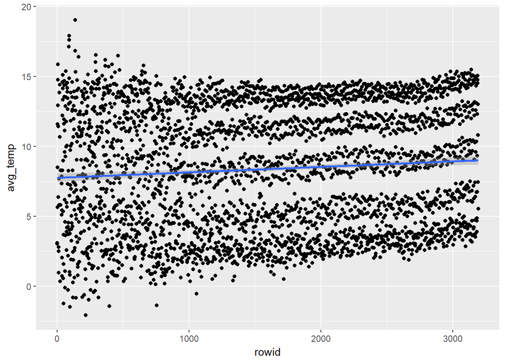

```r
temp_df %>%
  rowid_to_column() %>%
  ggplot(mapping=aes(y=avg_temp, x=rowid)) +
    geom_point() + geom_smooth(method=lm)
```

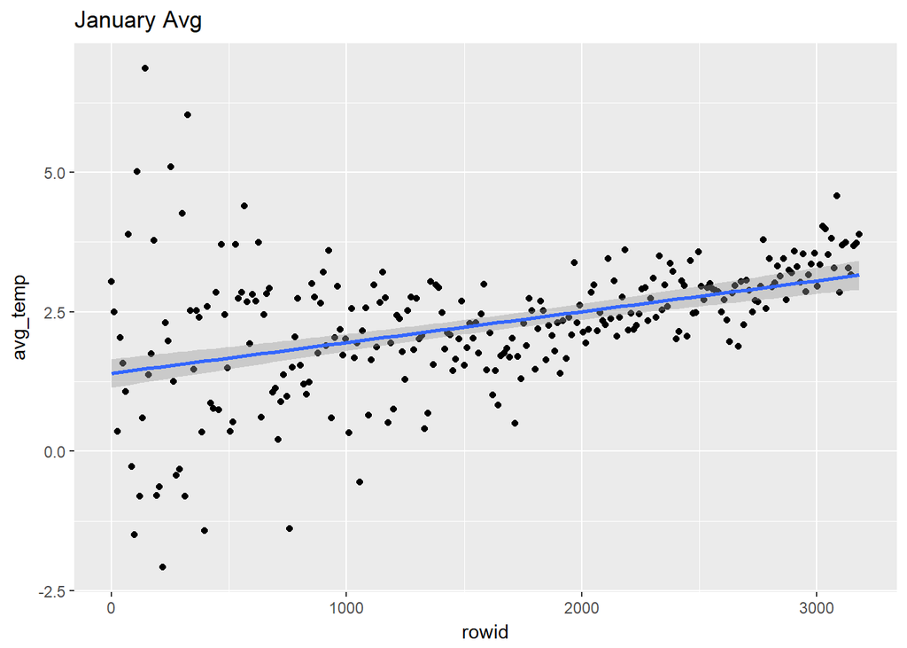

```r
temp_df %>%
  rowid_to_column() %>%
  filter(rowid %% 12 == 1) %>%
  ggplot(mapping=aes(y=avg_temp, x=rowid)) +
    geom_point() + geom_smooth(method=lm) + ggtitle("January Avg")
```

This appears to be a much better plot than the previous ones. Let’s repeat this process for the remaining months.

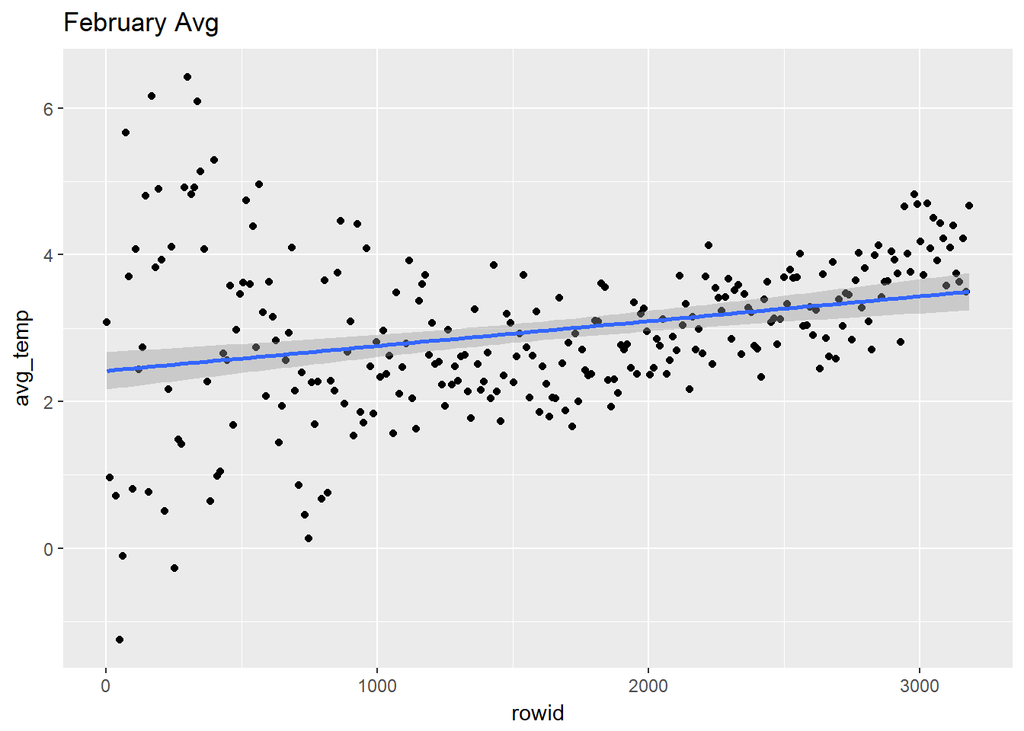

```r
temp_df %>%
  rowid_to_column() %>%
  filter(rowid %% 12 == 2) %>%
  ggplot(mapping=aes(y=avg_temp, x=rowid)) +
    geom_point() + geom_smooth(method=lm) + ggtitle("February Avg")
```

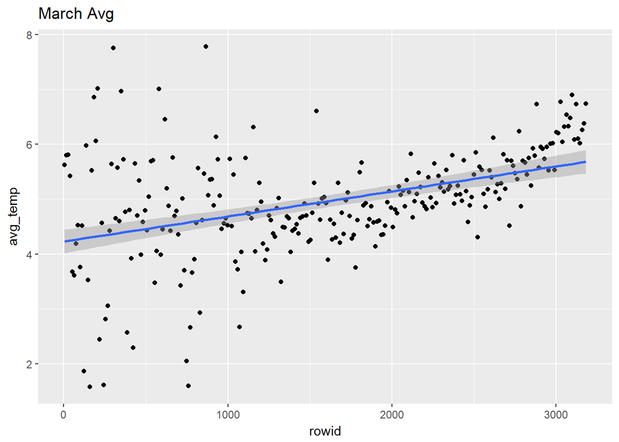

```r
temp_df %>%
  rowid_to_column() %>%
  filter(rowid %% 12 == 3) %>%
  ggplot(mapping=aes(y=avg_temp, x=rowid)) +
    geom_point() + geom_smooth(method=lm) + ggtitle("March Avg")
```

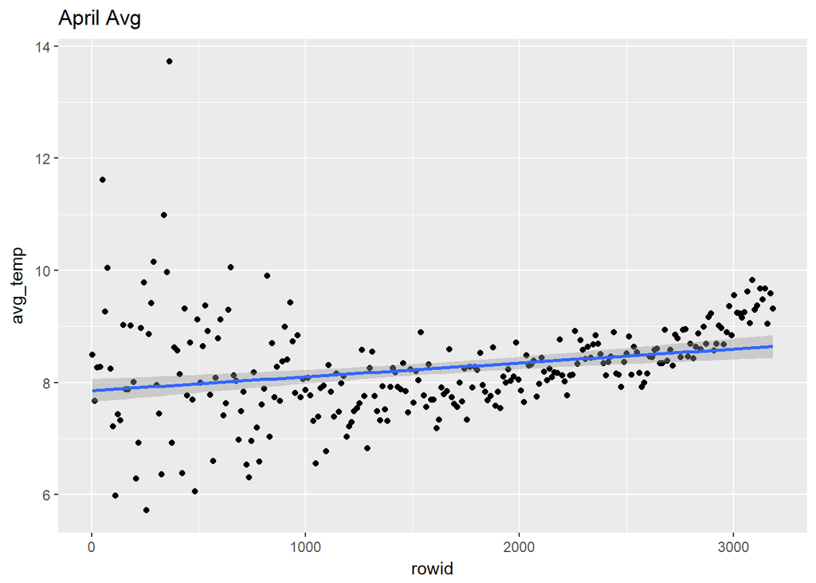

```r
temp_df %>%
  rowid_to_column() %>%
  filter(rowid %% 12 == 4) %>%
  ggplot(mapping=aes(y=avg_temp, x=rowid)) +
    geom_point() + geom_smooth(method=lm) + ggtitle("April Avg")
```

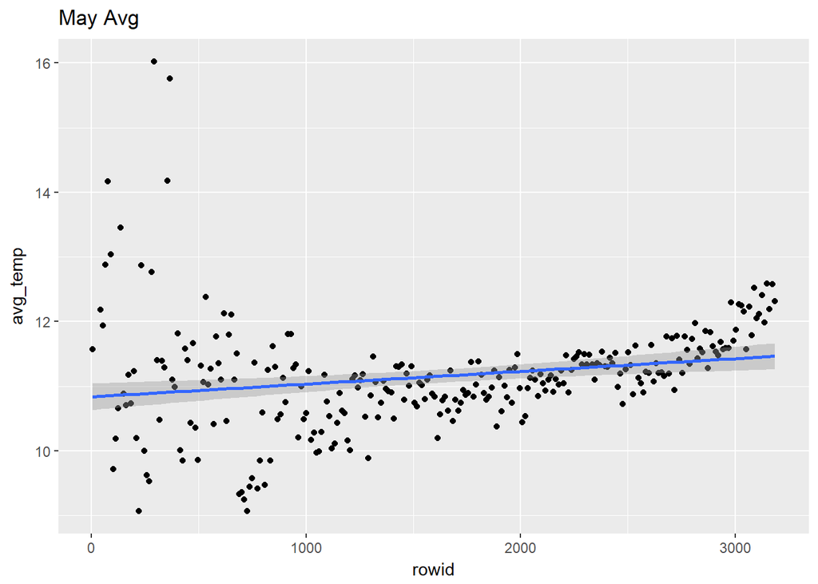

```r
temp_df %>%
  rowid_to_column() %>%
  filter(rowid %% 12 == 5) %>%
  ggplot(mapping=aes(y=avg_temp, x=rowid)) +
    geom_point() + geom_smooth(method=lm) + ggtitle("May Avg")
```

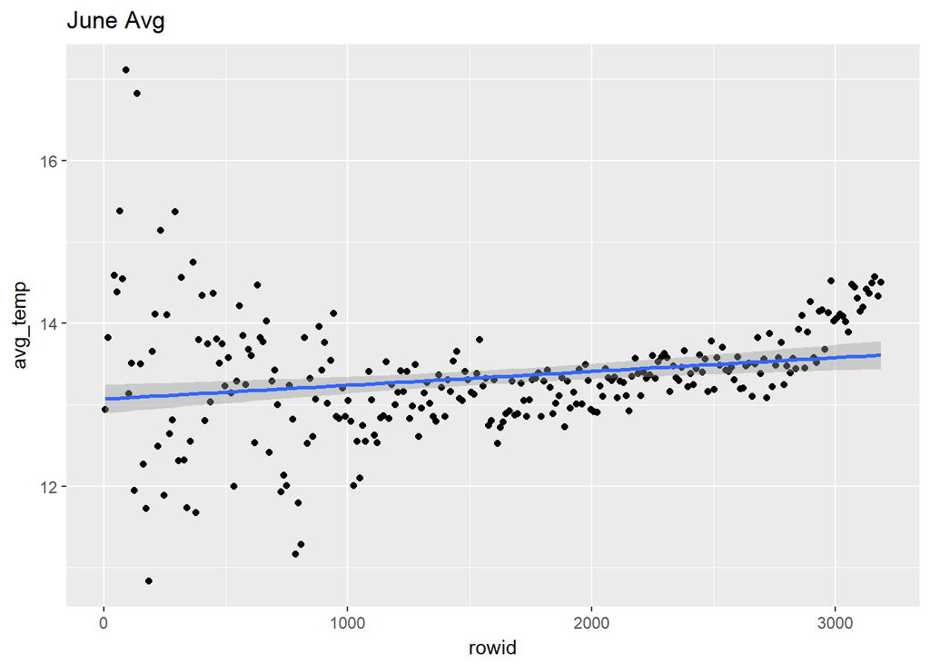

```r
temp_df %>%
  rowid_to_column() %>%
  filter(rowid %% 12 == 6) %>%
  ggplot(mapping=aes(y=avg_temp, x=rowid)) +
    geom_point() + geom_smooth(method=lm) + ggtitle("June Avg")
```

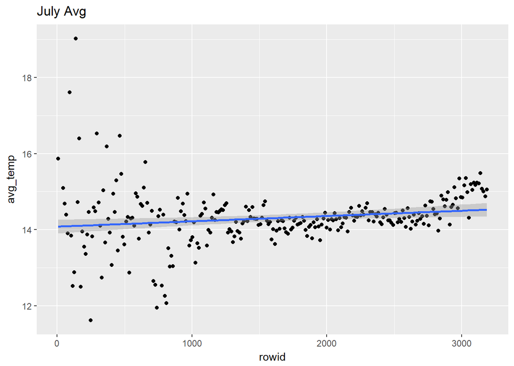

```r
temp_df %>%
  rowid_to_column() %>%
  filter(rowid %% 12 == 7) %>%
  ggplot(mapping=aes(y=avg_temp, x=rowid)) +
    geom_point() + geom_smooth(method=lm) + ggtitle("July Avg")
```

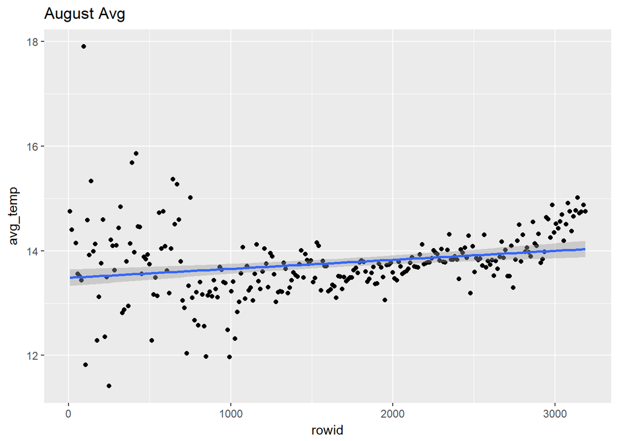

```r
temp_df %>%
  rowid_to_column() %>%
  filter(rowid %% 12 == 8) %>%
  ggplot(mapping=aes(y=avg_temp, x=rowid)) +
    geom_point() + geom_smooth(method=lm) + ggtitle("August Avg")
```

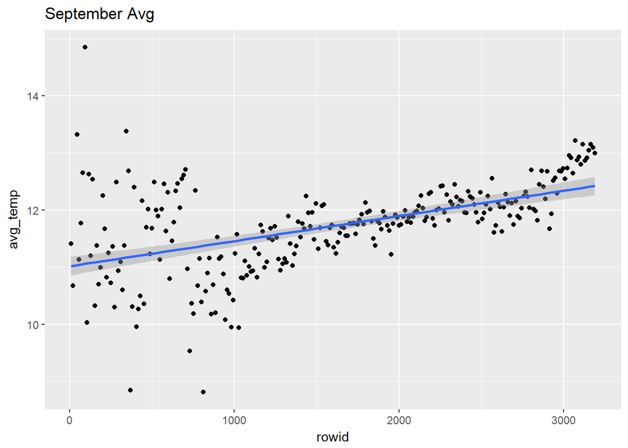

```r
temp_df %>%
  rowid_to_column() %>%
  filter(rowid %% 12 == 9) %>%
  ggplot(mapping=aes(y=avg_temp, x=rowid)) +
    geom_point() + geom_smooth(method=lm) + ggtitle("September Avg")
```

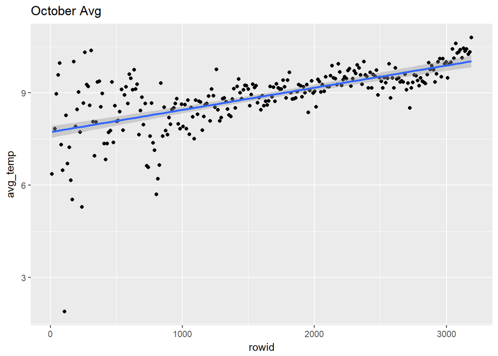

```r
temp_df %>%
  rowid_to_column() %>%
  filter(rowid %% 12 == 10) %>%
  ggplot(mapping=aes(y=avg_temp, x=rowid)) +
    geom_point() + geom_smooth(method=lm) + ggtitle("October Avg")
```

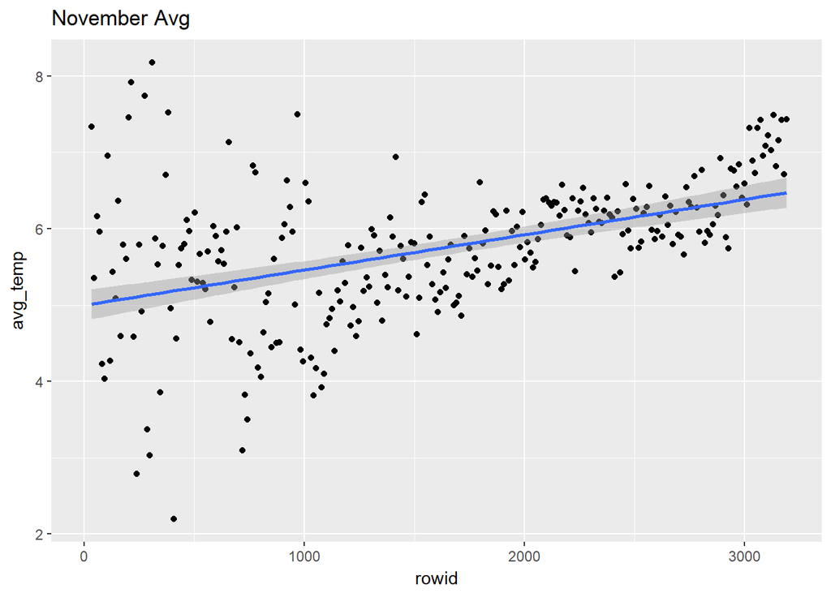

```r
temp_df %>%
  rowid_to_column() %>%
  filter(rowid %% 12 == 11) %>%
  ggplot(mapping=aes(y=avg_temp, x=rowid)) +
    geom_point() + geom_smooth(method=lm) + ggtitle("November Avg")
```

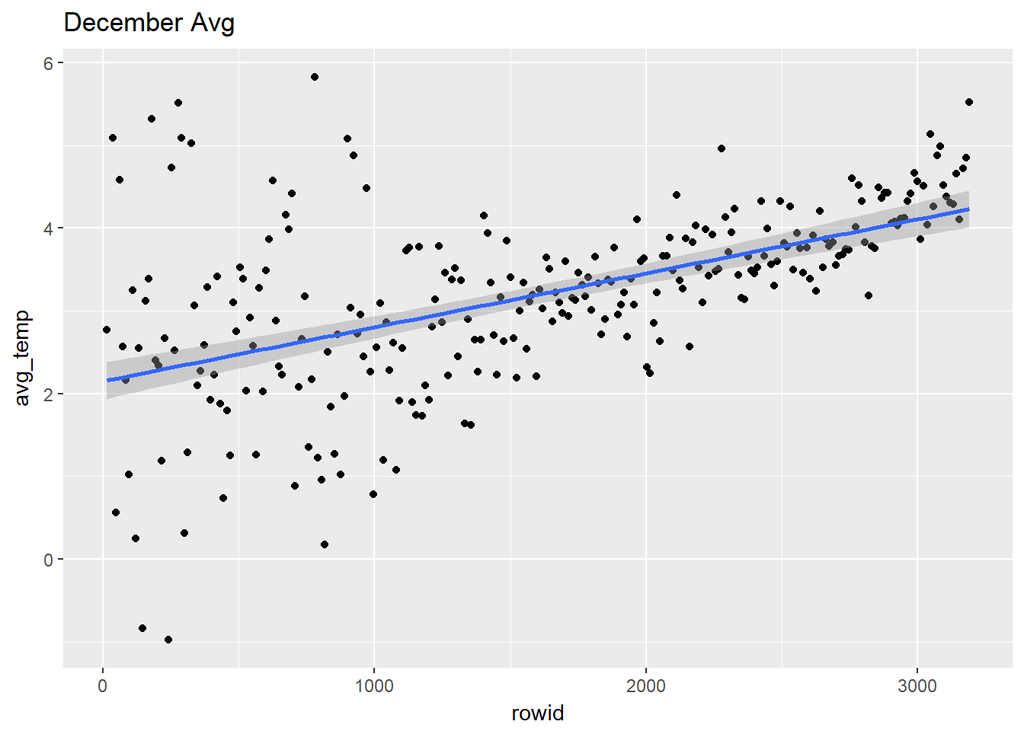

```r
temp_df %>%
  rowid_to_column() %>%
  filter(rowid %% 12 == 0) %>%
  ggplot(mapping=aes(y=avg_temp, x=rowid)) +
    geom_point() + geom_smooth(method=lm) + ggtitle("December Avg")
```

Let’s confirm whether a linear model is appropriate for this data by plotting the residuals against the time for each month.

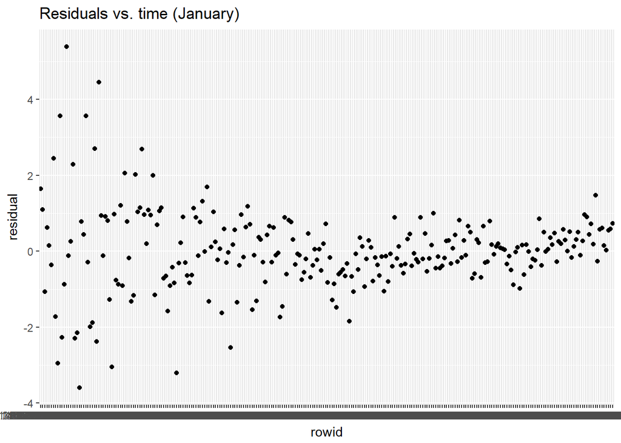

```r
temp_df_jan <- temp_df %>%
  rowid_to_column() %>%
  filter(rowid %% 12 == 1)

lm(avg_temp~rowid, data=temp_df_jan) %>%
  augment() %>%
  ggplot(aes(x=factor(.fitted), y=.resid)) +
    geom_point() +
    labs(title="Residuals vs. time (January)",
         x = "rowid",
         y = "residual")
```

So far, this looks good. The values are centered around 0 and there does not appear to be a linear correlation between the residual and time. There is a presence of high residuals in the beginning in both the positive and negative directions.

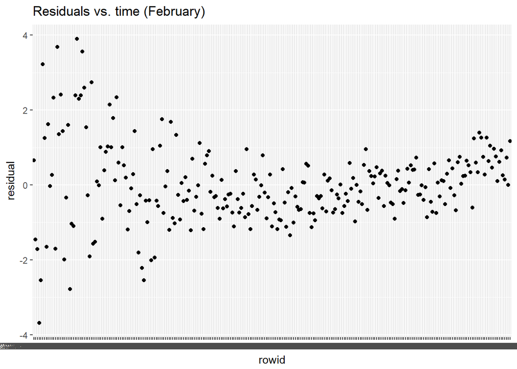

```r
temp_df_feb <- temp_df %>%
  rowid_to_column() %>%
  filter(rowid %% 12 == 2)

lm(avg_temp~rowid, data=temp_df_feb) %>%
  augment() %>%
  ggplot(aes(x=factor(.fitted), y=.resid)) +
    geom_point() +
    labs(title="Residuals vs. time (February)",
         x = "rowid",
         y = "residual")
```

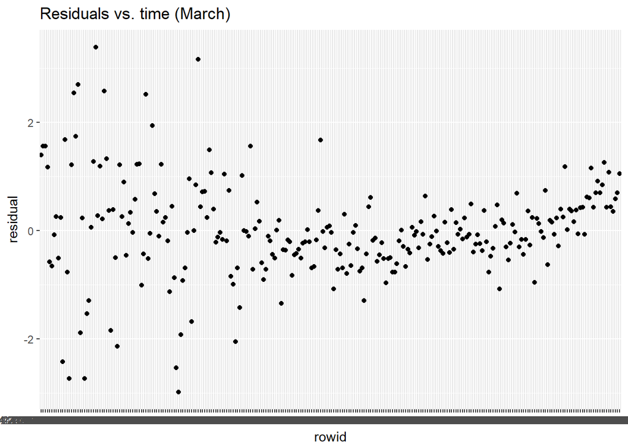

```r
temp_df_mar <- temp_df %>%
  rowid_to_column() %>%
  filter(rowid %% 12 == 3)

lm(avg_temp~rowid, data=temp_df_mar) %>%
  augment() %>%
  ggplot(aes(x=factor(.fitted), y=.resid)) +
    geom_point() +
    labs(title="Residuals vs. time (March)",
         x = "rowid",
         y = "residual")
```

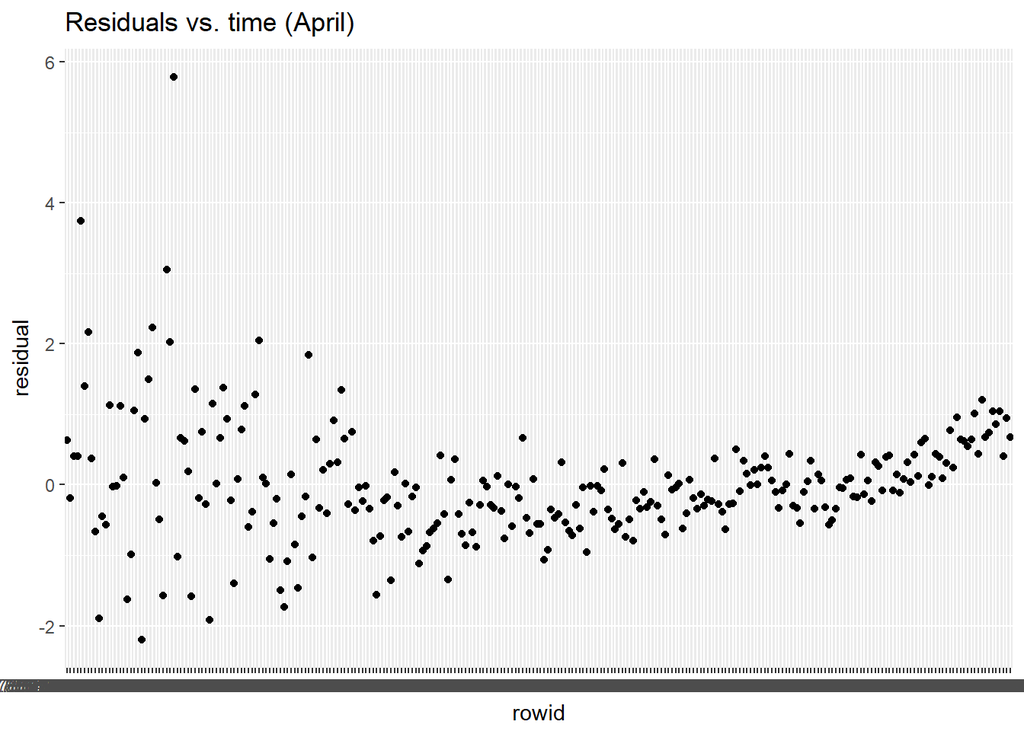

```r
temp_df_apr <- temp_df %>%
  rowid_to_column() %>%
  filter(rowid %% 12 == 4)

lm(avg_temp~rowid, data=temp_df_apr) %>%
  augment() %>%
  ggplot(aes(x=factor(.fitted), y=.resid)) +
    geom_point() +
    labs(title="Residuals vs. time (April)",
         x = "rowid",
         y = "residual")
```

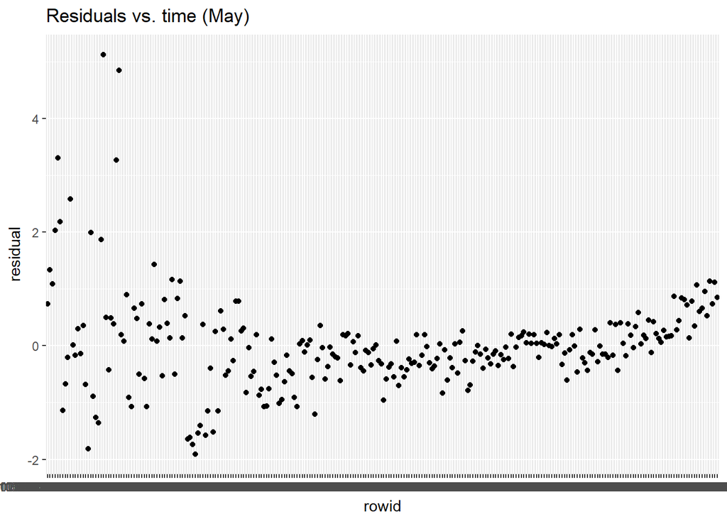

```r
temp_df_may <- temp_df %>%
  rowid_to_column() %>%
  filter(rowid %% 12 == 5)

lm(avg_temp~rowid, data=temp_df_may) %>%
  augment() %>%
  ggplot(aes(x=factor(.fitted), y=.resid)) +
    geom_point() +
    labs(title="Residuals vs. time (May)",
         x = "rowid",
         y = "residual")
```

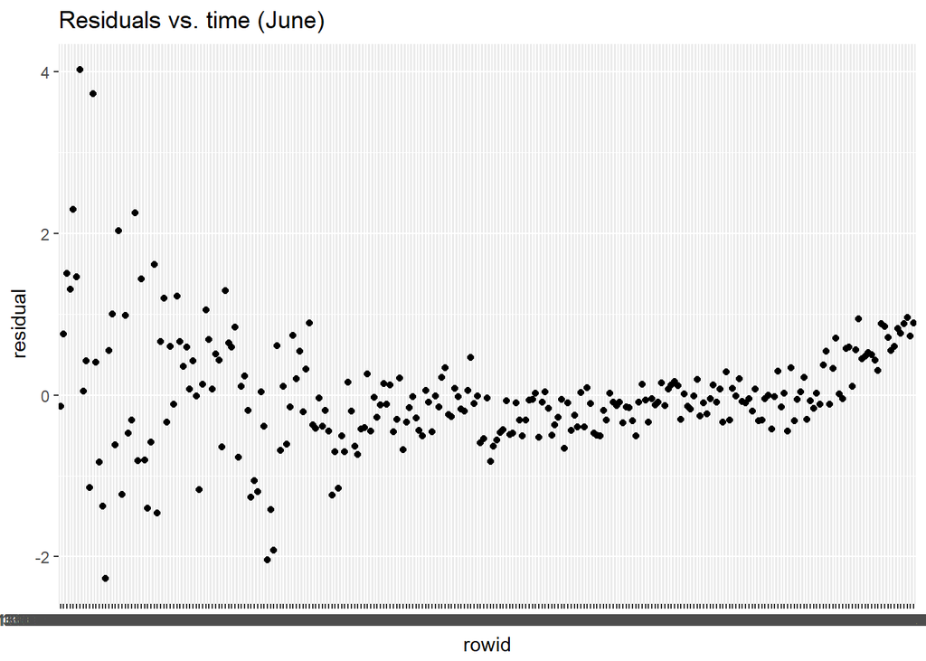

```r
temp_df_jun <- temp_df %>%
  rowid_to_column() %>%
  filter(rowid %% 12 == 6)

lm(avg_temp~rowid, data=temp_df_jun) %>%
  augment() %>%
  ggplot(aes(x=factor(.fitted), y=.resid)) +
    geom_point() +
    labs(title="Residuals vs. time (June)",
         x = "rowid",
         y = "residual")
```

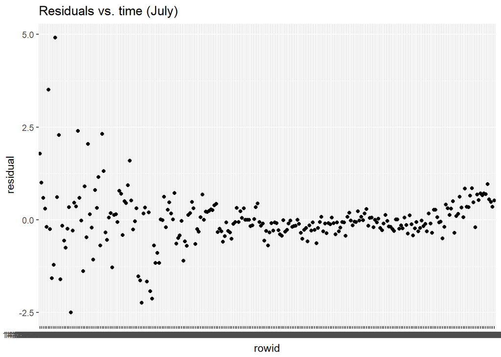

```r
temp_df_jul <- temp_df %>%
  rowid_to_column() %>%
  filter(rowid %% 12 == 7)

lm(avg_temp~rowid, data=temp_df_jul) %>%
  augment() %>%
  ggplot(aes(x=factor(.fitted), y=.resid)) +
    geom_point() +
    labs(title="Residuals vs. time (July)",
         x = "rowid",
         y = "residual")
```

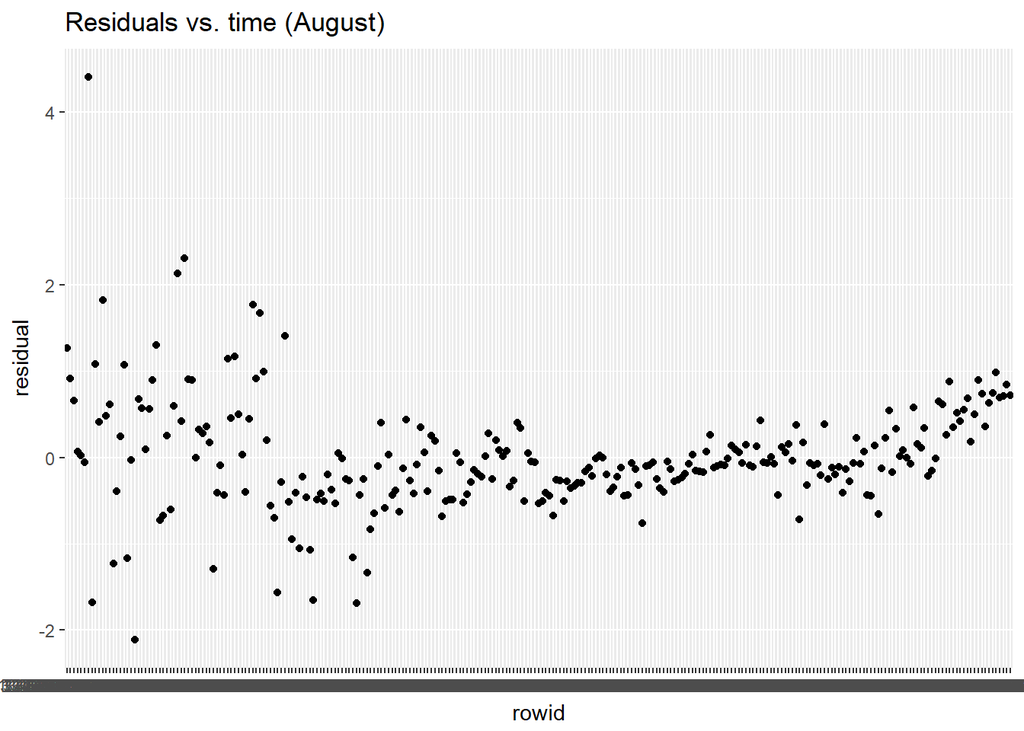

```r
temp_df_aug <- temp_df %>%
  rowid_to_column() %>%
  filter(rowid %% 12 == 8)

lm(avg_temp~rowid, data=temp_df_aug) %>%
  augment() %>%
  ggplot(aes(x=factor(.fitted), y=.resid)) +
    geom_point() +
    labs(title="Residuals vs. time (August)",
         x = "rowid",
         y = "residual")
```

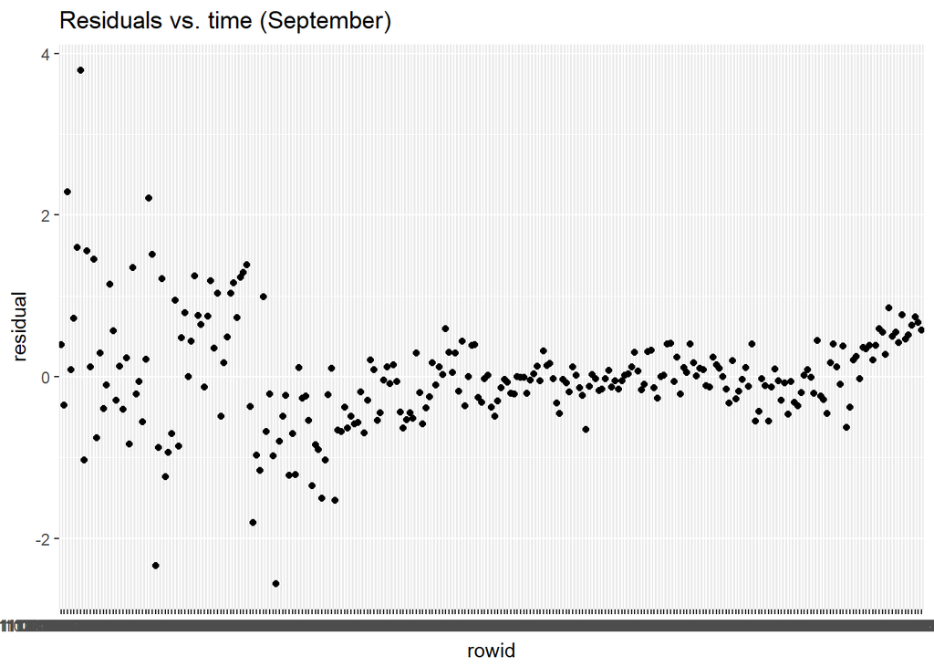

```r
temp_df_sep <- temp_df %>%
  rowid_to_column() %>%
  filter(rowid %% 12 == 9)

lm(avg_temp~rowid, data=temp_df_sep) %>%
  augment() %>%
  ggplot(aes(x=factor(.fitted), y=.resid)) +
    geom_point() +
    labs(title="Residuals vs. time (September)",
         x = "rowid",
         y = "residual")
```

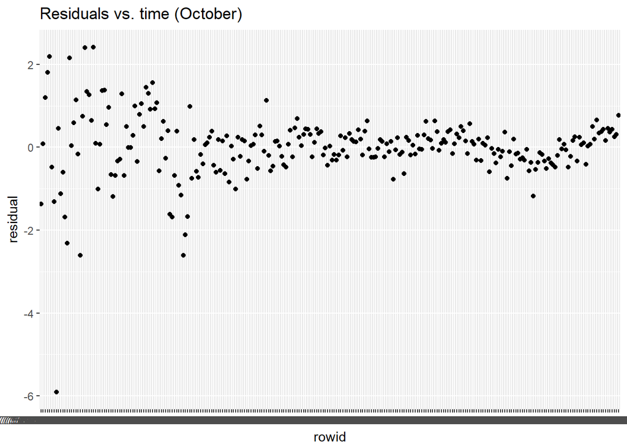

```r
temp_df_oct <- temp_df %>%
  rowid_to_column() %>%
  filter(rowid %% 12 == 10)

lm(avg_temp~rowid, data=temp_df_oct) %>%
  augment() %>%
  ggplot(aes(x=factor(.fitted), y=.resid)) +
    geom_point() +
    labs(title="Residuals vs. time (October)",
         x = "rowid",
         y = "residual")
```

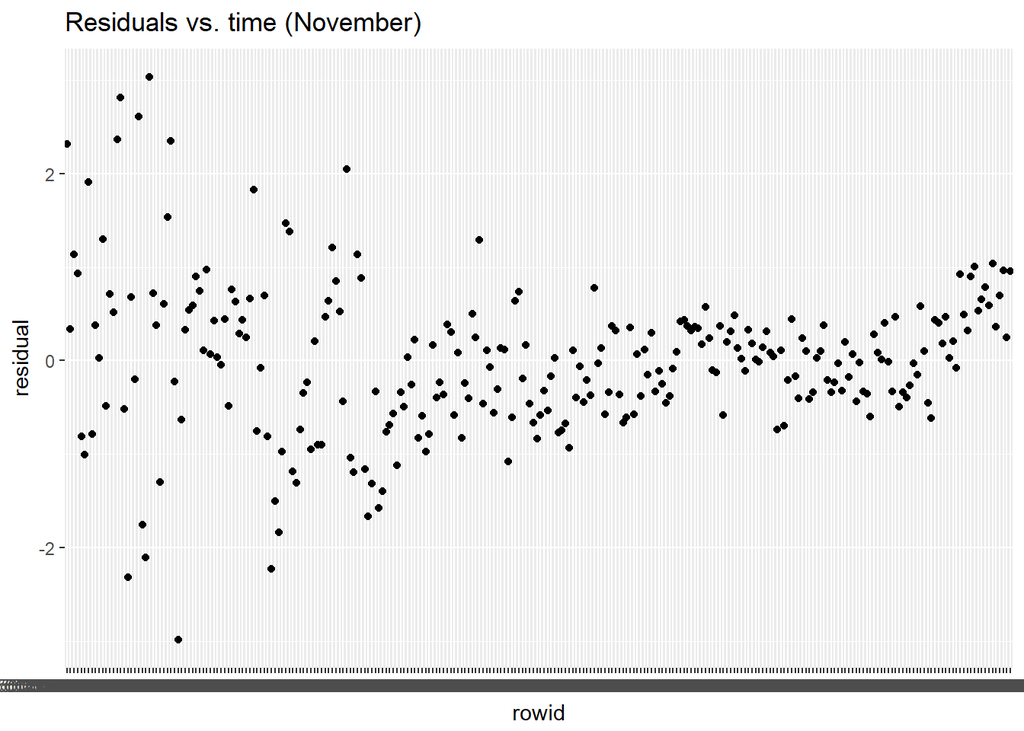

```r
temp_df_nov <- temp_df %>%
  rowid_to_column() %>%
  filter(rowid %% 12 == 11)

lm(avg_temp~rowid, data=temp_df_nov) %>%
  augment() %>%
  ggplot(aes(x=factor(.fitted), y=.resid)) +
    geom_point() +
    labs(title="Residuals vs. time (November)",
         x = "rowid",
         y = "residual")
```

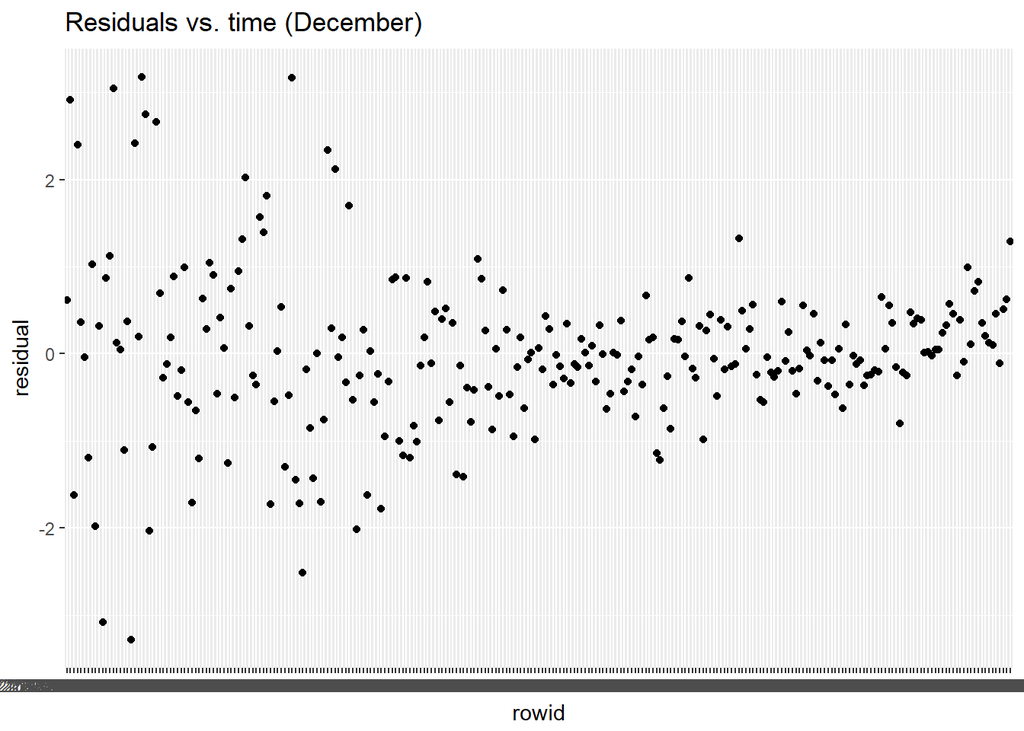

```r
temp_df_dec <- temp_df %>%
  rowid_to_column() %>%
  filter(rowid %% 12 == 0)

lm(avg_temp~rowid, data=temp_df_dec) %>%
  augment() %>%
  ggplot(aes(x=factor(.fitted), y=.resid)) +
    geom_point() +
    labs(title="Residuals vs. time (December)",
         x = "rowid",
         y = "residual")
```

Let’s try plotting the distributions of average temperatures in January. To simplify the plot I will split the rowids into groups by cutting a total of 19 chunks. I chose 19 because there are 266 values per month and 19 is a common factor.

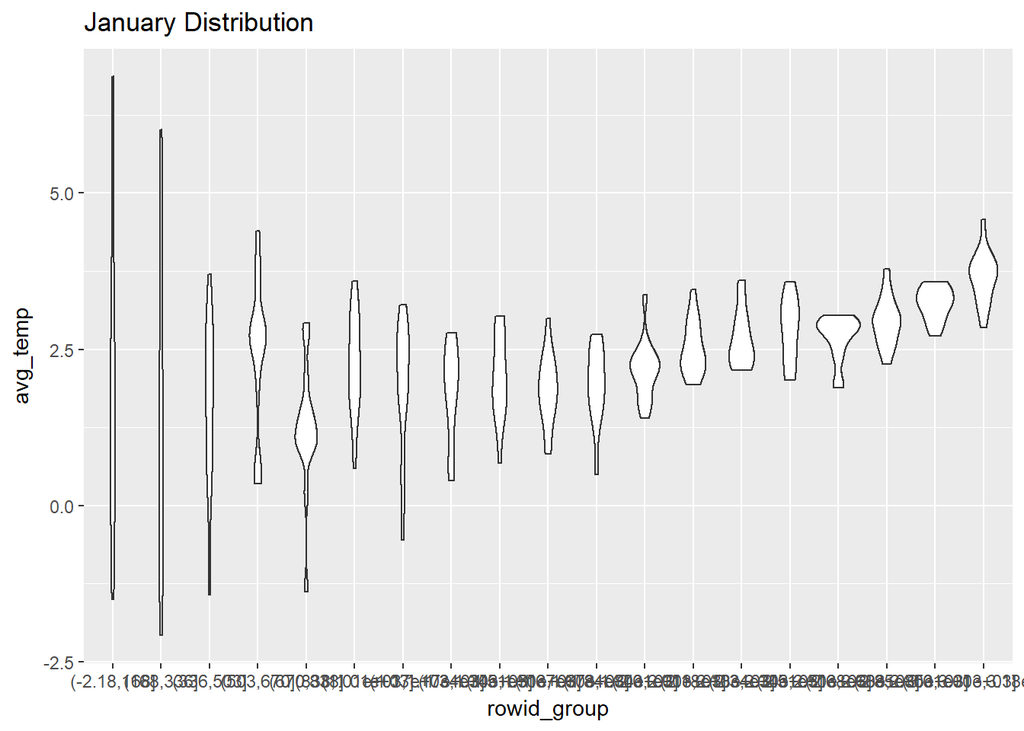

```r
temp_df_jan <- temp_df_jan %>%
  mutate(rowid_group = cut(rowid, breaks=19))

temp_df_jan %>%
  ggplot(mapping=aes(y=avg_temp, x=rowid_group)) +
    geom_violin() + geom_smooth(method=lm) + ggtitle("January Distribution")
```

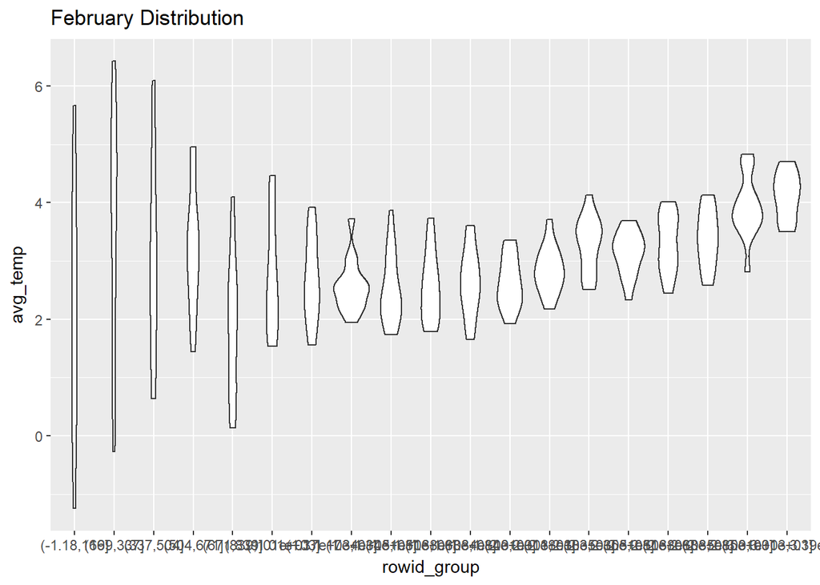

```r
temp_df_feb <- temp_df_feb %>%
  mutate(rowid_group = cut(rowid, breaks=19))

temp_df_feb %>%
  ggplot(mapping=aes(y=avg_temp, x=rowid_group)) +
    geom_violin() + geom_smooth(method=lm) + ggtitle("February Distribution")
```

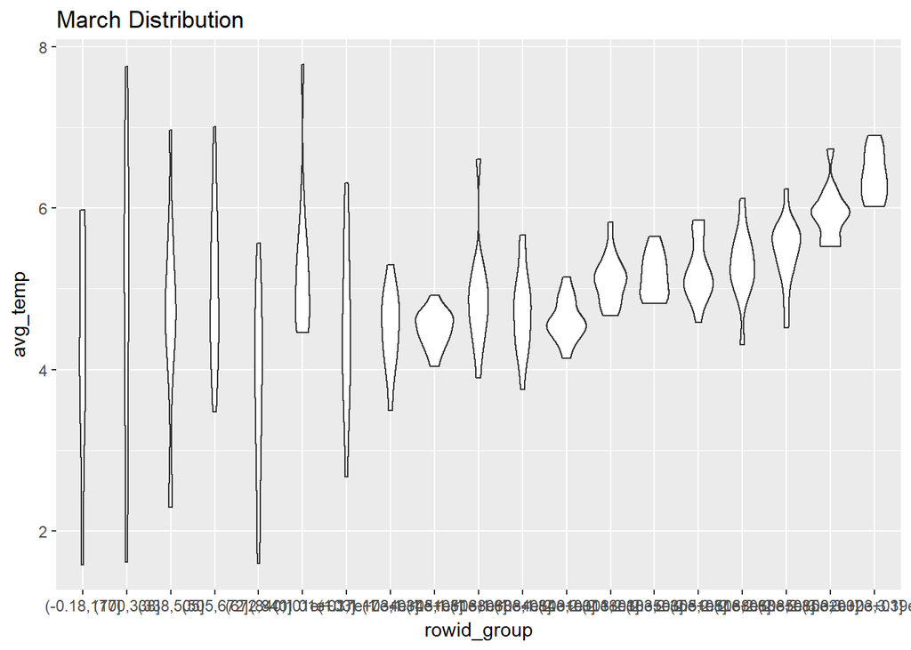

```r
temp_df_mar <- temp_df_mar %>%
  mutate(rowid_group = cut(rowid, breaks=19))

temp_df_mar %>%
  ggplot(mapping=aes(y=avg_temp, x=rowid_group)) +
    geom_violin() + geom_smooth(method=lm) + ggtitle("March Distribution")
```

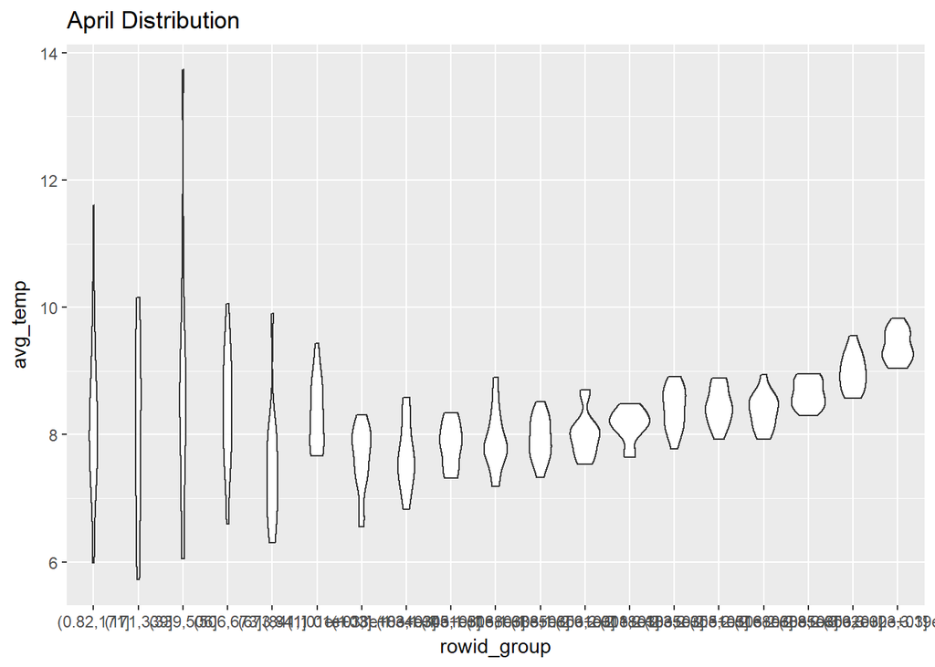

```r
temp_df_apr <- temp_df_apr %>%
  mutate(rowid_group = cut(rowid, breaks=19))

temp_df_apr %>%
  ggplot(mapping=aes(y=avg_temp, x=rowid_group)) +
    geom_violin() + geom_smooth(method=lm) + ggtitle("April Distribution")
```